# Logistic Regression

Angelina Khatiwada

08 06 2021

## Dataset infromation

Data was collected via a survey on Amazon Mechanical Turk. The survey describes different driving scenarios including the destination, current time, weather, passenger, etc., and then ask the person whether he will accept the coupon if he is the driver.

- Multivariate dataset
- Number of Instances: 12684
- Number of Attributes: 23
- Associated Tasks: Classification
- Missing Values: Yes

Some features meaning:

- Bar: never, less1, 1~3, gt8, nan4~8 (feature meaning: how many times do you go to a bar every month?)
- CoffeeHouse: never, less1, 4~8, 1~3, gt8, nan (feature meaning: how many times do you go to a coffeehouse every month?)
- CarryAway:n4~8, 1~3, gt8, less1, never (feature meaning: how many times do you get take-away food every month?)
- RestaurantLessThan20: 4~8, 1~3, less1, gt8, never (feature meaning: how many times do you go to a restaurant with an average expense per person of less than $20 every month?)
- Restaurant20To50: 1~3, less1, never, gt8, 4~8, nan (feature meaning: how many times do you go to a restaurant with average expense per person of $20 - $50 every month?)
- toCoupon_GEQ15min:0,1 (feature meaning: driving distance to the restaurant/bar for using the coupon is greater than 15 minutes)
- toCoupon_GEQ25min:0, 1 (feature meaning: driving distance to the restaurant/bar for using the coupon is greater than 25 minutes)
- direction_same:0, 1 (feature meaning: whether the restaurant/bar is in the same direction as your current destination)
- direction_opp:1, 0 (feature meaning: whether the restaurant/bar is in the same direction as your current destination)
- Y:1, 0 (whether the coupon is accepted)

Source: https://archive.ics.uci.edu/ml/datasets/in-vehicle+coupon+recommendation

```r
library(dplyr)
library(skimr)
library(ggplot2)
library(tidyr)
#library(fastDummies)
library(caret)
library(grid)
library(gridExtra)
library("epitools")
library(pROC)
library(MASS)
```

## Data import and summary

```r
data  <- read.csv("https://raw.githubusercontent.com/rijinbaby/Statistical-Learning/main/in-vehicle-coupon-recommendation.csv",
                 header=T, na.strings=c("","NA"))
dim(data)
```

```
## [1] 12684    26
```

```r
str(data) #data types
```

```
## 'data.frame':    12684 obs. of  26 variables:
##  $ destination         : chr  "No Urgent Place" "No Urgent Place" "No Urgent Place" "No Urgent Place" ...
##  $ passanger           : chr  "Alone" "Friend(s)" "Friend(s)" "Friend(s)" ...
##  $ weather             : chr  "Sunny" "Sunny" "Sunny" "Sunny" ...
##  $ temperature         : int  55 80 80 80 80 80 55 80 80 80 ...
##  $ time                : chr  "2PM" "10AM" "10AM" "2PM" ...
##  $ coupon              : chr  "Restaurant(<20)" "Coffee House" "Carry out & Take away" "Coffee House" ...
##  $ expiration          : chr  "1d" "2h" "2h" "2h" ...
##  $ gender              : chr  "Female" "Female" "Female" "Female" ...
##  $ age                 : chr  "21" "21" "21" "21" ...
##  $ maritalStatus       : chr  "Unmarried partner" "Unmarried partner" "Unmarried partner" "Unmarried partner" ...
##  $ has_children        : int  1 1 1 1 1 1 1 1 1 1 ...
##  $ education           : chr  "Some college - no degree" "Some college - no degree" "Some college - no degree" "Some college - no degree" ...
##  $ occupation          : chr  "Unemployed" "Unemployed" "Unemployed" "Unemployed" ...
##  $ income              : chr  "$37500 - $49999" "$37500 - $49999" "$37500 - $49999" "$37500 - $49999" ...
##  $ car                 : chr  NA NA NA NA ...
##  $ Bar                 : chr  "never" "never" "never" "never" ...
##  $ CoffeeHouse         : chr  "never" "never" "never" "never" ...
##  $ CarryAway           : chr  NA NA NA NA ...
##  $ RestaurantLessThan20: chr  "4~8" "4~8" "4~8" "4~8" ...
##  $ Restaurant20To50    : chr  "1~3" "1~3" "1~3" "1~3" ...
##  $ toCoupon_GEQ5min    : int  1 1 1 1 1 1 1 1 1 1 ...
##  $ toCoupon_GEQ15min   : int  0 0 1 1 1 1 1 1 1 1 ...
##  $ toCoupon_GEQ25min   : int  0 0 0 0 0 0 0 0 0 0 ...
##  $ direction_same      : int  0 0 0 0 0 0 0 0 0 0 ...
##  $ direction_opp       : int  1 1 1 1 1 1 1 1 1 1 ...
##  $ Y                   : int  1 0 1 0 0 1 1 1 1 0 ...
```

```r
#glimpse(data)
#summary(data)
skim(data) #checking for NA values, unique value in the column
```

Data summary

| Name | data |
| --- | --- |
| Number of rows | 12684 |
| Number of columns | 26 |
| _______________________ |  |
| Column type frequency: |  |
| character | 18 |
| numeric | 8 |
| ________________________ |  |
| Group variables | None |

**Variable type: character**

| skim_variable | n_missing | complete_rate | min | max | empty | n_unique | whitespace |
| --- | --- | --- | --- | --- | --- | --- | --- |
| destination | 0 | 1.00 | 4 | 15 | 0 | 3 | 0 |
| passanger | 0 | 1.00 | 5 | 9 | 0 | 4 | 0 |
| weather | 0 | 1.00 | 5 | 5 | 0 | 3 | 0 |
| time | 0 | 1.00 | 3 | 4 | 0 | 5 | 0 |
| coupon | 0 | 1.00 | 3 | 21 | 0 | 5 | 0 |
| expiration | 0 | 1.00 | 2 | 2 | 0 | 2 | 0 |
| gender | 0 | 1.00 | 4 | 6 | 0 | 2 | 0 |
| age | 0 | 1.00 | 2 | 7 | 0 | 8 | 0 |
| maritalStatus | 0 | 1.00 | 6 | 17 | 0 | 5 | 0 |
| education | 0 | 1.00 | 16 | 38 | 0 | 6 | 0 |
| occupation | 0 | 1.00 | 5 | 41 | 0 | 25 | 0 |
| income | 0 | 1.00 | 15 | 16 | 0 | 9 | 0 |
| car | 12576 | 0.01 | 6 | 40 | 0 | 5 | 0 |
| Bar | 107 | 0.99 | 3 | 5 | 0 | 5 | 0 |
| CoffeeHouse | 217 | 0.98 | 3 | 5 | 0 | 5 | 0 |
| CarryAway | 151 | 0.99 | 3 | 5 | 0 | 5 | 0 |
| RestaurantLessThan20 | 130 | 0.99 | 3 | 5 | 0 | 5 | 0 |
| Restaurant20To50 | 189 | 0.99 | 3 | 5 | 0 | 5 | 0 |

**Variable type: numeric**

| skim_variable | n_missing | complete_rate | mean | sd | p0 | p25 | p50 | p75 | p100 | hist |
| --- | --- | --- | --- | --- | --- | --- | --- | --- | --- | --- |
| temperature | 0 | 1 | 63.30 | 19.15 | 30 | 55 | 80 | 80 | 80 | ▃▁▅▁▇ |
| has_children | 0 | 1 | 0.41 | 0.49 | 0 | 0 | 0 | 1 | 1 | ▇▁▁▁▆ |
| toCoupon_GEQ5min | 0 | 1 | 1.00 | 0.00 | 1 | 1 | 1 | 1 | 1 | ▁▁▇▁▁ |
| toCoupon_GEQ15min | 0 | 1 | 0.56 | 0.50 | 0 | 0 | 1 | 1 | 1 | ▆▁▁▁▇ |
| toCoupon_GEQ25min | 0 | 1 | 0.12 | 0.32 | 0 | 0 | 0 | 0 | 1 | ▇▁▁▁▁ |
| direction_same | 0 | 1 | 0.21 | 0.41 | 0 | 0 | 0 | 0 | 1 | ▇▁▁▁▂ |
| direction_opp | 0 | 1 | 0.79 | 0.41 | 0 | 1 | 1 | 1 | 1 | ▂▁▁▁▇ |
| Y | 0 | 1 | 0.57 | 0.50 | 0 | 0 | 1 | 1 | 1 | ▆▁▁▁▇ |

There are NULL values and columns with unique values that should be removed.

## Plotting data

```r
coupon_data  <- read.csv("https://raw.githubusercontent.com/rijinbaby/Statistical-Learning/main/cleaned_data_raw_columns.csv")
coupon_data$Y <- as.character(coupon_data$Y)
```

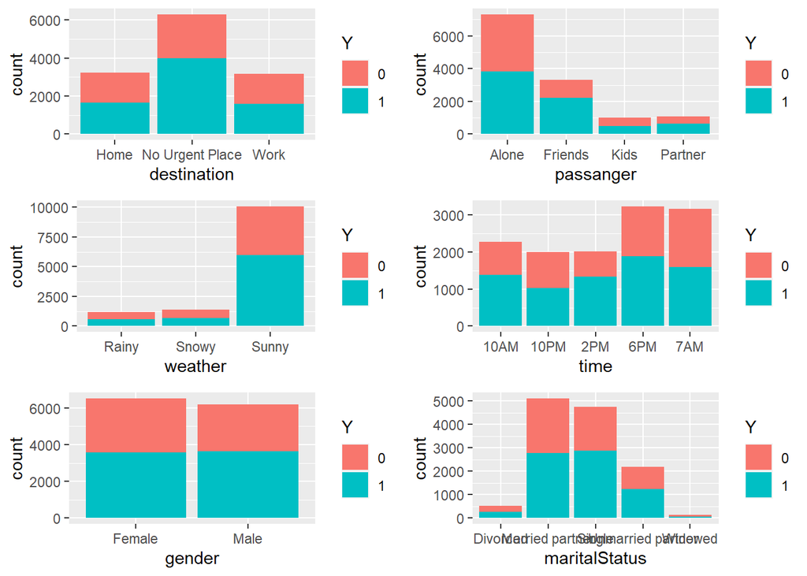

```r
#Destination
p1 <- ggplot(coupon_data, aes(x=destination, fill=Y)) +
    geom_bar(stat="count")

#passanger
p2 <- ggplot(coupon_data, aes(x=passanger, fill=Y)) +
  geom_bar(stat="count")

#weather
p3 <- ggplot(coupon_data, aes(x=weather, fill=Y)) +
  geom_bar(stat="count")

#time
p4 <- ggplot(coupon_data, aes(x=time, fill=Y)) +
  geom_bar(stat="count")

#gender
p5 <- ggplot(coupon_data, aes(x=gender, fill=Y)) +
  geom_bar(stat="count")

#maritalStatus
p6 <- ggplot(coupon_data, aes(x=maritalStatus, fill=Y)) +
  geom_bar(stat="count")

grid.arrange(p1, p2, p3, p4, p5, p6, ncol=2)
```

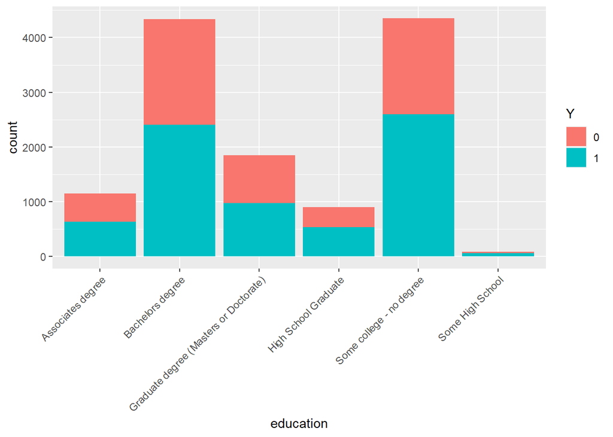

```r
#education
p7 <- ggplot(coupon_data, aes(x=education, fill=Y)) +
  geom_bar(stat="count")+
  theme(axis.text.x = element_text(angle = 45, hjust = 1))
p7
```

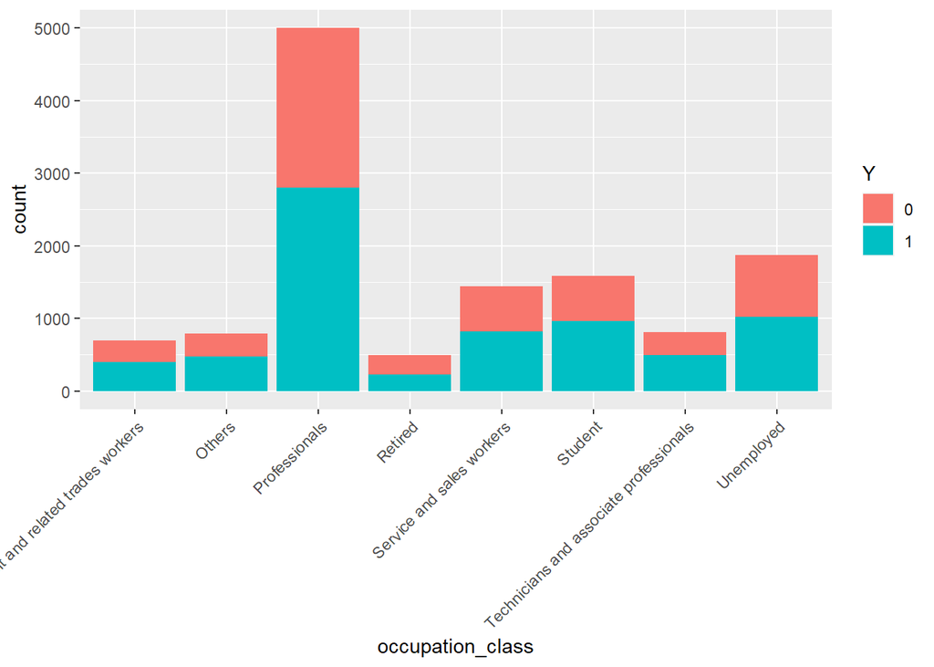

```r
#occupation
p8 <- ggplot(coupon_data, aes(x=occupation_class, fill=Y)) +
  geom_bar(stat="count")+
  theme(axis.text.x = element_text(angle = 45, hjust = 1))
p8
```

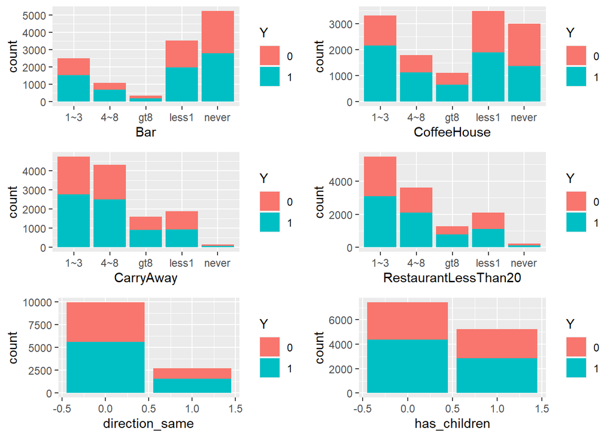

```r
#Bar
p9 <- ggplot(coupon_data, aes(x=Bar, fill=Y)) +
  geom_bar(stat="count")

#CoffeeHouse
p10 <- ggplot(coupon_data, aes(x=CoffeeHouse, fill=Y)) +
  geom_bar(stat="count")

#CarryAway
p11 <- ggplot(coupon_data, aes(x=CarryAway, fill=Y)) +
  geom_bar(stat="count")

#RestaurantLessThan20
p12 <- ggplot(coupon_data, aes(x=RestaurantLessThan20, fill=Y)) +
  geom_bar(stat="count")

#direction_same
p13 <- ggplot(coupon_data, aes(x=direction_same, fill=Y)) +
  geom_bar(stat="count")

#has_children
p14 <- ggplot(coupon_data, aes(x=has_children, fill=Y)) +
  geom_bar(stat="count")

grid.arrange(p9, p10, p11, p12, p13, p14, ncol=2)
```

**For numeric variables**

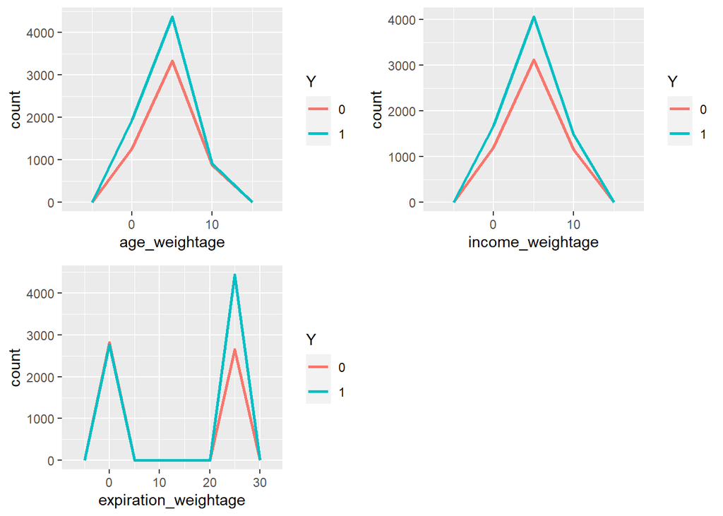

```r
#Age histogram
p15 <- ggplot(data = coupon_data, aes(age_weightage, color = Y))+
  geom_freqpoly(binwidth = 5, size = 1)

#Income histogram
p16 <- ggplot(data = coupon_data, aes(income_weightage, color = Y))+
  geom_freqpoly(binwidth = 5, size = 1)

#Expiration histogram
p17 <- ggplot(data = coupon_data, aes(expiration_weightage, color = Y))+
  geom_freqpoly(binwidth = 5, size = 1)

grid.arrange(p15, p16, p17, ncol=2)
```

## Modeling

### Train-test split

```r
coupon_data_encoded  <- read.csv("https://raw.githubusercontent.com/rijinbaby/Statistical-Learning/main/cleaned_data_encoded.csv")

drops= c("direction_opp_1") #drop additional correlated variables
coupon_data_encoded <- coupon_data_encoded[ , !(colnames(coupon_data_encoded) %in% drops)]
coupon_data_encoded$Y <-as.factor(coupon_data_encoded$Y)
```

We created dummy variables, removing the first dummy variable created from each column. This is done to avoid multicollinearity in a multiple regression model caused by included all dummy variables.

```r
#train/test split

set.seed(123)
split_train_test  <- createDataPartition(coupon_data_encoded$Y, p = .67,
                                  list = FALSE,
                                  times = 1)

train <- coupon_data_encoded[ split_train_test,]
test  <- coupon_data_encoded[-split_train_test,]
```

## Logistic Regression

**Running Cross-Validation with k = 10 folds**

```r
# CV  with 10 folds
train_control <- trainControl(method = "cv", number = 10)

# train the model on training set
log_reg <- train(Y ~.,
               data = train,
               trControl = train_control,
               method = "glm",
               family=binomial(link='logit'))

log_reg
```

```
## Generalized Linear Model
##
## 8499 samples
##   61 predictor
##    2 classes: '0', '1'
##
## No pre-processing
## Resampling: Cross-Validated (10 fold)
## Summary of sample sizes: 7650, 7649, 7649, 7650, 7649, 7648, ...
## Resampling results:
##
##   Accuracy   Kappa
##   0.6897341  0.3588724
```

```r
summary(log_reg)
```

```
##
## Call:
## NULL
##
## Deviance Residuals:
##     Min       1Q   Median       3Q      Max
## -2.3991  -1.0221   0.5615   0.9404   2.4739
##
## Coefficients: (1 not defined because of singularities)
##                                                           Estimate Std. Error
## (Intercept)                                              -1.895462   0.311437
## age_weightage                                            -0.022402   0.015167
## income_weightage                                         -0.011069   0.011279
## expiration_weightage                                      0.037100   0.002416
## destination_No.Urgent.Place                               0.790621   0.118271
## destination_Work                                          0.076562   0.115048
## passanger_Friends                                         0.255149   0.093650
## passanger_Kids                                           -0.371167   0.114514
## passanger_Partner                                         0.311705   0.105800
## weather_Snowy                                             0.257764   0.164050
## weather_Sunny                                             0.589673   0.098589
## temperature_55                                            0.430028   0.118497
## temperature_80                                            0.216601   0.105416
## time_6PM                                                  0.266063   0.097977
## time_7AM                                                        NA         NA
## time_10AM                                                 0.135255   0.091748
## time_10PM                                                -0.132745   0.102898
## coupon_Carry.out...Take.away                              1.813844   0.090413
## coupon_Coffee.House                                       0.549265   0.079743
## coupon_Restaurant..20.                                    1.576761   0.087530
## coupon_Restaurant.20.50.                                  0.477336   0.098906
## gender_Male                                               0.221749   0.052155
## maritalStatus_Married.partner                             0.074102   0.136022
## maritalStatus_Single                                      0.165630   0.141668
## maritalStatus_Unmarried.partner                          -0.058789   0.145731
## maritalStatus_Widowed                                    -0.164906   0.267775
## has_children_1                                            0.064422   0.069910
## education_Bachelors.degree                               -0.139768   0.094605
## education_Graduate.degree..Masters.or.Doctorate.         -0.349217   0.110722
## education_High.School.Graduate                            0.262941   0.126604
```

[output cut: 90 more lines]

```
## occupation_class_Retired                                  -0.102 0.918743
## occupation_class_Service.and.sales.workers                 0.706 0.480048
## occupation_class_Student                                  -0.026 0.979160
## occupation_class_Technicians.and.associate.professionals   1.775 0.075828 .
## occupation_class_Unemployed                               -0.053 0.957696
## ---
## Signif. codes:  0 '***' 0.001 '**' 0.01 '*' 0.05 '.' 0.1 ' ' 1
##
## (Dispersion parameter for binomial family taken to be 1)
##
##     Null deviance: 11622  on 8498  degrees of freedom
## Residual deviance: 10006  on 8438  degrees of freedom
## AIC: 10128
##
## Number of Fisher Scoring iterations: 4
```

### Predictions

**Model accuracy and Confusion matrix**

```r
log_reg_prob1 <- predict(log_reg, test, type = 'prob')
log_reg_pred1 <- ifelse(log_reg_prob1[2] > 0.5, 1, 0)
mean(log_reg_pred1 == test$Y)
```

```
## [1] 0.6783751
```

```r
table(Predicted = log_reg_pred1, Actual = test$Y)
```

```
##          Actual
## Predicted    0    1
##         0 1019  559
##         1  787 1820
```

```r
confusionMatrix(
  as.factor(log_reg_pred1),
  as.factor(test$Y),
  positive = "1"
)
```

```
## Confusion Matrix and Statistics
##
##           Reference
## Prediction    0    1
##          0 1019  559
##          1  787 1820
##
##                Accuracy : 0.6784
##                  95% CI : (0.664, 0.6925)
##     No Information Rate : 0.5685
##     P-Value [Acc > NIR] : < 2.2e-16
##
##                   Kappa : 0.3343
##
##  Mcnemar's Test P-Value : 6.119e-10
##
##             Sensitivity : 0.7650
##             Specificity : 0.5642
##          Pos Pred Value : 0.6981
##          Neg Pred Value : 0.6458
##              Prevalence : 0.5685
##          Detection Rate : 0.4349
##    Detection Prevalence : 0.6229
##       Balanced Accuracy : 0.6646
##
##        'Positive' Class : 1
##
```

High sensitivity: fewer False Negative errors. Low specificity: Many False Positive. We can change the threshold 0.5 and set a higher threshold to balance these values.

```r
log_reg_prob1 <- predict(log_reg, test, type = 'prob')
log_reg_pred1 <- ifelse(log_reg_prob1[2] > 0.55, 1, 0)
mean(log_reg_pred1 == test$Y)
```

```
## [1] 0.6810036
```

```r
confusionMatrix(
  as.factor(log_reg_pred1),
  as.factor(test$Y),
  positive = "1"
)
```

```
## Confusion Matrix and Statistics
##
##           Reference
## Prediction    0    1
##          0 1172  701
##          1  634 1678
##
##                Accuracy : 0.681
##                  95% CI : (0.6666, 0.6951)
##     No Information Rate : 0.5685
##     P-Value [Acc > NIR] : < 2e-16
##
##                   Kappa : 0.3527
##
##  Mcnemar's Test P-Value : 0.07086
##
##             Sensitivity : 0.7053
##             Specificity : 0.6489
##          Pos Pred Value : 0.7258
##          Neg Pred Value : 0.6257
##              Prevalence : 0.5685
##          Detection Rate : 0.4010
##    Detection Prevalence : 0.5524
##       Balanced Accuracy : 0.6771
##
##        'Positive' Class : 1
##
```

**ROC curve**

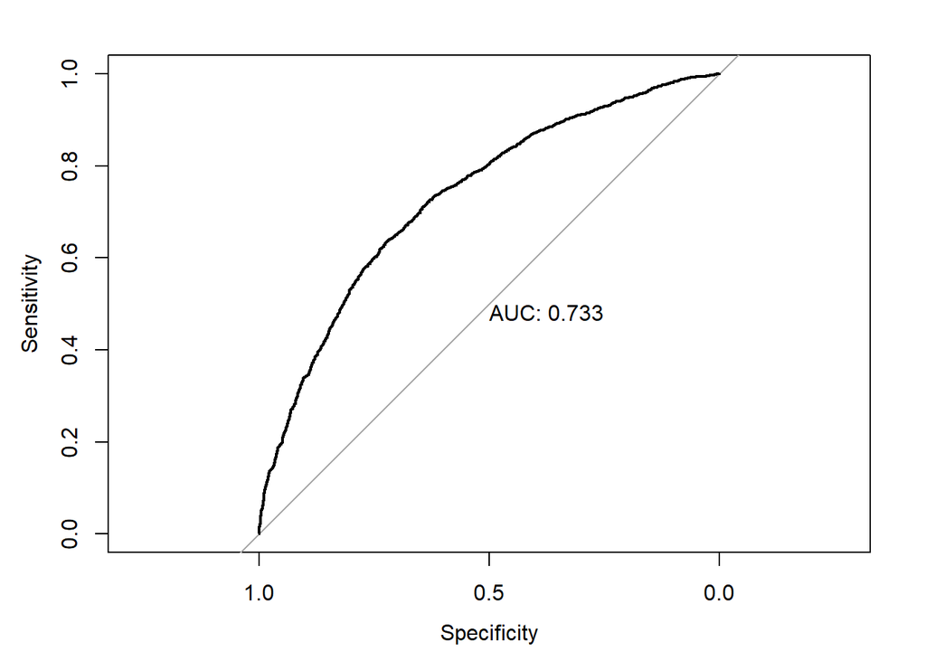

```r
test_roc = roc(test$Y ~ log_reg_prob1$"1", plot = TRUE, print.auc = TRUE)
```

## Linear Discriminant Analysis

```r
lda.fit=lda(Y~.,data = train)
lda.fit
```

```
## Call:
## lda(Y ~ ., data = train)
##
## Prior probabilities of groups:
##         0         1
## 0.4315802 0.5684198
##
## Group means:
##   age_weightage income_weightage expiration_weightage
## 0      4.387950         4.795256             12.79607
## 1      4.138895         4.685158             15.57524
##   destination_No.Urgent.Place destination_Work passanger_Friends passanger_Kids
## 0                   0.4209378        0.2870774         0.1984733     0.08969466
## 1                   0.5549576        0.2196233         0.3044918     0.07120679
##   passanger_Partner weather_Snowy weather_Sunny temperature_55 temperature_80
## 0        0.08069793    0.13331516     0.7489095      0.3290622      0.4738277
## 1        0.09314842    0.09232043     0.8298489      0.2862761      0.5435728
##    time_6PM  time_7AM time_10AM time_10PM coupon_Carry.out...Take.away
## 0 0.2483642 0.2870774 0.1633043 0.1796619                    0.1090513
## 1 0.2622645 0.2196233 0.1937487 0.1399296                    0.2411509
##   coupon_Coffee.House coupon_Restaurant..20. coupon_Restaurant.20.50.
## 0           0.3710469              0.1496728               0.15130862
## 1           0.2777893              0.2769613               0.09169944
##   gender_Male maritalStatus_Married.partner maritalStatus_Single
## 0   0.4612868                     0.4201200            0.3454198
## 1   0.5056924                     0.3877044            0.3930863
##   maritalStatus_Unmarried.partner maritalStatus_Widowed has_children_1
## 0                       0.1761178           0.015267176      0.4375682
## 1                       0.1718071           0.008693852      0.3968123
##   education_Bachelors.degree education_Graduate.degree..Masters.or.Doctorate.
## 0                  0.3546892                                        0.1559433
## 1                  0.3361623                                        0.1324777
##   education_High.School.Graduate education_Some.college...no.degree
## 0                     0.06733915                          0.3241549
## 1                     0.07555372                          0.3595529
##   education_Some.High.School    Bar_4.8    Bar_gt8 Bar_less1 Bar_never
## 0                0.005179935 0.07142857 0.02753544 0.2827154 0.4443839
## 1                0.009107845 0.09459739 0.02939350 0.2831712 0.3783896
##   CoffeeHouse_4.8 CoffeeHouse_gt8 CoffeeHouse_less1 CoffeeHouse_never
## 0       0.1183206      0.08342421         0.2884406         0.3004362
```

[output cut: 77 more lines]

```
## RestaurantLessThan20_never                                0.417853937
## Restaurant20To50_4.8                                      0.093753564
## Restaurant20To50_gt8                                      0.135436613
## Restaurant20To50_less1                                   -0.229214789
## Restaurant20To50_never                                   -0.346001947
## toCoupon_GEQ15min_1                                      -0.120731963
## toCoupon_GEQ25min_1                                       0.166064416
## direction_same_1                                          0.635807261
## occupation_class_Others                                   0.248734805
## occupation_class_Professionals                            0.102641620
## occupation_class_Retired                                 -0.014990692
## occupation_class_Service.and.sales.workers                0.113530345
## occupation_class_Student                                  0.002916319
## occupation_class_Technicians.and.associate.professionals  0.290523604
## occupation_class_Unemployed                               0.002976102
```

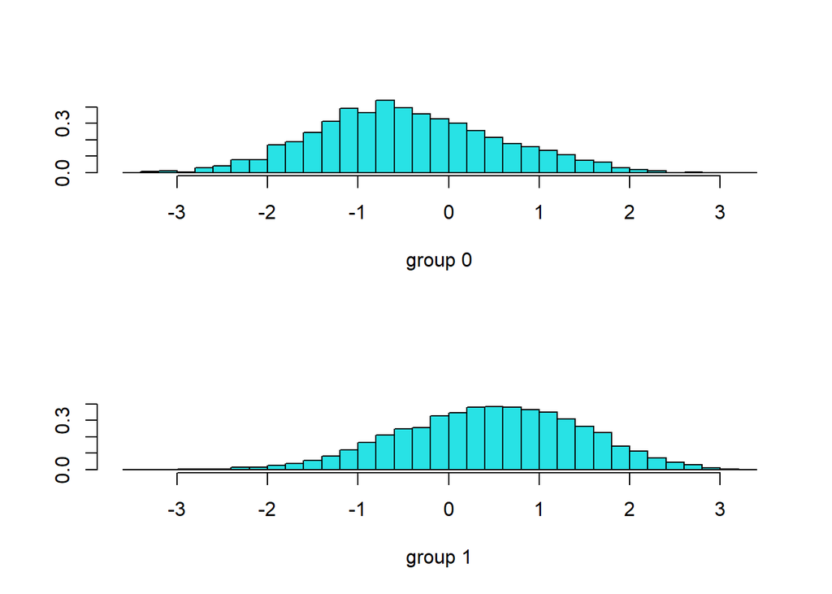

```r
plot(lda.fit)
```

```r
lda.pred=predict(lda.fit,test)$class
table(lda.pred,test$Y)
```

```
##
## lda.pred    0    1
##        0 1030  567
##        1  776 1812
```

```r
mean(lda.pred==test$Y)
```

```
## [1] 0.679092
```

## Association Rules

```r
assoc <- xtabs(~Y+destination_No.Urgent.Place, data=coupon_data_encoded)
assoc
```

```
##    destination_No.Urgent.Place
## Y      0    1
##   0 3173 2301
##   1 3228 3982
```

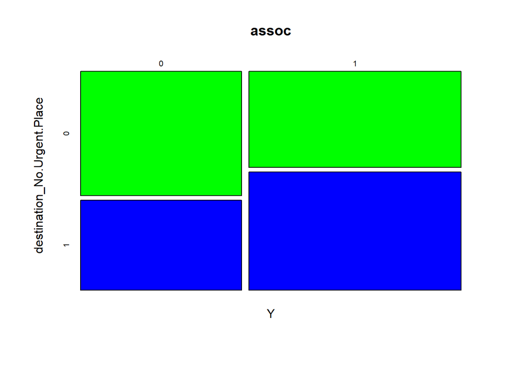

```r
plot(assoc, col=c("green","blue"))
```

**Testing significance**

```r
Test <- chisq.test(assoc, correct=FALSE)
Test
```

```
##
##  Pearson's Chi-squared test
##
## data:  assoc
## X-squared = 216.68, df = 1, p-value < 2.2e-16
```

Chi2 is 216, relation between the variables is significant (p-value< 0.05). We reject H0 about independence between variables, however, there is no perfect association

```r
riskratio.wald(table(coupon_data_encoded$destination_No.Urgent.Place,coupon_data_encoded$Y))
```

```
## $data
##
##            0    1 Total
##   0     3173 3228  6401
##   1     2301 3982  6283
##   Total 5474 7210 12684
##
## $measure
##    risk ratio with 95% C.I.
##     estimate    lower    upper
##   0 1.000000       NA       NA
##   1 1.256749 1.218739 1.295945
##
## $p.value
##    two-sided
##     midp.exact fisher.exact   chi.square
##   0         NA           NA           NA
##   1          0 3.584379e-49 4.791965e-49
##
## $correction
## [1] FALSE
##
## attr(,"method")
## [1] "Unconditional MLE & normal approximation (Wald) CI"
```

```r
oddsratio.wald(table(coupon_data_encoded$destination_No.Urgent.Place,coupon_data_encoded$Y))
```

```
## $data
##
##            0    1 Total
##   0     3173 3228  6401
##   1     2301 3982  6283
##   Total 5474 7210 12684
##
## $measure
##    odds ratio with 95% C.I.
##     estimate    lower    upper
##   0 1.000000       NA       NA
##   1 1.701066 1.584546 1.826154
##
## $p.value
##    two-sided
##     midp.exact fisher.exact   chi.square
##   0         NA           NA           NA
##   1          0 3.584379e-49 4.791965e-49
##
## $correction
## [1] FALSE
##
## attr(,"method")
## [1] "Unconditional MLE & normal approximation (Wald) CI"
```

Confidence interval does not include 1 - reject H0 about independence. Odds: odds under no urgent place/ odds under other cases = 1.70

```r
lr_fit <- glm(Y ~ destination_No.Urgent.Place, data = coupon_data_encoded,
              family=binomial(link='logit'))
summary(lr_fit)
```

```
##
## Call:
## glm(formula = Y ~ destination_No.Urgent.Place, family = binomial(link = "logit"),
##     data = coupon_data_encoded)
##
## Deviance Residuals:
##    Min      1Q  Median      3Q     Max
## -1.417  -1.185   0.955   1.170   1.170
##
## Coefficients:
##                             Estimate Std. Error z value Pr(>|z|)
## (Intercept)                  0.01719    0.02500   0.687    0.492
## destination_No.Urgent.Place  0.53126    0.03620  14.674   <2e-16 ***
## ---
## Signif. codes:  0 '***' 0.001 '**' 0.01 '*' 0.05 '.' 0.1 ' ' 1
##
## (Dispersion parameter for binomial family taken to be 1)
##
##     Null deviance: 17345  on 12683  degrees of freedom
## Residual deviance: 17128  on 12682  degrees of freedom
## AIC: 17132
##
## Number of Fisher Scoring iterations: 4
```

```r
exp(cbind(OR = coef(lr_fit), confint(lr_fit)))
```

```
##                                   OR     2.5 %   97.5 %
## (Intercept)                 1.017334 0.9686898 1.068428
## destination_No.Urgent.Place 1.701066 1.5846381 1.826267
```

Odds ratio of 1.70 means that the odds that coupon accepted with destination_No Urgent Place was 1.70 times higher than the odds among controls. Destination_No Urgent Place might be a factor.